# Deep Learning for NLP

### Reducing network size

The simplest way to prevent overfitting is to reduce the size of the model. In other words, to reduce the number of parameters in the model (i.e. the number of layers and the number of units per layer). In deep learning, the number of learnable parameters in a model is often referred to as the model’s *capacity*. A model with more parameters has more “memorization capacity” and therefore can easily learn a perfect mapping between training samples and their targets: a mapping without any generalization power.

[figure not shown]

Thus, reducing the number of parameters to avoid overfitting is one of the most common approaches in statistics.

```r
model <- keras_model_sequential() %>%
layer_dense(units = 4, activation = "relu", input_shape = c(10000)) %>%
layer_dense(units = 4, activation = "relu") %>%
layer_dense(units = 1, activation = "sigmoid")

model %>% compile(
  optimizer = "rmsprop",
  loss = "binary_crossentropy",
  metrics = c("accuracy")
  )

history2 <- model %>% fit(
  partial_x_train,
  partial_y_train,
  epochs = 20,
  batch_size = 512,
  validation_data = list(x_val, y_val)
)
```

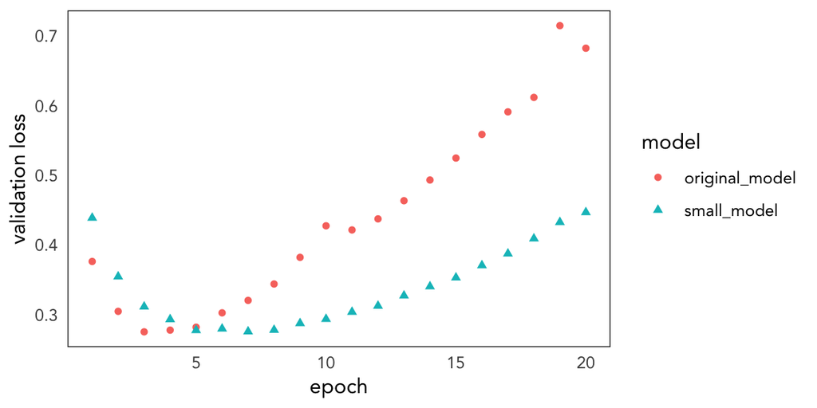

```r
df <- tibble(
  original_model = history$metrics$val_loss,
  small_model = history2$metrics$val_loss,
  epoch = 1:20)

df %>%
  gather(1:2, key = model, value = loss) %>%
  ggplot(aes(x = epoch, y = loss, color = model, shape = model)) +
  geom_point() +
  labs(y = "validation loss")
```

The smaller network starts overfitting later than the original network, and its performance degrades much more slowly once it starts overfitting.

### Regularization

A common way to reduce overfitting is to put constraints on the complexity of a network by stopping its weights from taking large values. This is called *weight regularization*, and it’s done by slightly modifying the network’s loss function by penalizing large weights.

This cost comes in two forms:

- *L1 regularization*: The cost added is proportional to the *absolute value* of the weight coefficients (we call this LASSO in the context of regression).
- *L2 regularization*: The cost added is proportional to the *square of the value* of the weight coefficients. L2 regularization is also called *weight decay* in the context of neural networks (in other context we call this Ridge regression).

```r
model <- keras_model_sequential() %>%
  layer_dense(units = 16, activation = "relu", input_shape = c(10000),
              kernel_regularizer = regularizer_l2(0.001)) %>%
  layer_dense(units = 16, activation = "relu",
              kernel_regularizer = regularizer_l2(0.001)) %>%
  layer_dense(units = 1, activation = "sigmoid")

model %>% compile(
  optimizer = "rmsprop",
  loss = "binary_crossentropy",
  metrics = c("accuracy")
  )

history3 <- model %>% fit(
  partial_x_train,
  partial_y_train,
  epochs = 20,
  batch_size = 512,
  validation_data = list(x_val, y_val)
)
```

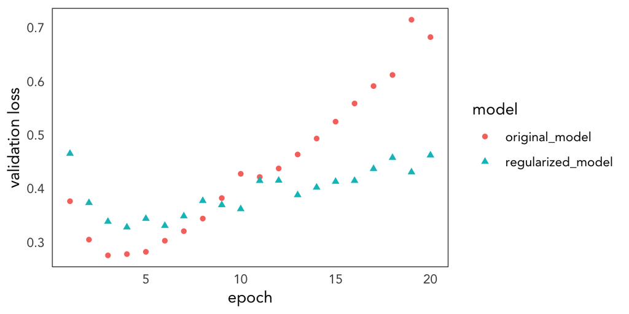

```r
df <- tibble(
  original_model = history$metrics$val_loss,
  regularized_model = history3$metrics$val_loss,
  epoch = 1:20)

df %>%
  gather(1:2, key = model, value = loss) %>%
  ggplot(aes(x = epoch, y = loss, color = model, shape = model)) +
  geom_point() +
  labs(y = "validation loss")
```

Note that because this penalty is *only added at training time*, the loss for this network will be much higher at training time than at test time.

### Dropout

*Dropout* is one of the most common and effective regularization techniques for neural networks. It’s applied to individual layers and consists of randomly dropping out (setting to zero) a number of output features of the layer during training. The *dropout rate* is the fraction of the features that are zeroed out (usually between 0.2 and 0.5). At test time, no units are dropped out; instead, the layer’s output values are scaled down by a factor equal to the dropout rate, to balance for the fact that more units are active than at training time.

So, for example, let’s say a given layer returns the following vector:

$$\pmatrix{0.2 \\ 0.5 \\ 1.3 \\ 0.8 \\ 1.1} \overset{\text{dropout}}{\longrightarrow} \pmatrix{0 \\ 0.5 \\ 1.3 \\ 0 \\ 1.1}$$

In code:

```r
## Dropout during training
layer_output <- layer_output * sample(x = 0:1,
                                      size = length(layer_output),
                                      replace = TRUE)
## Test time (scaling down)
layer_output <- layer_output * 0.5
```

This technique obviously sounds obscure and arbitrary. It was first developed by Geoffrey Hinton, who was inspired by, among other things, a fraud-prevention mechanism used by banks.

In his words:

> I went to my bank. The tellers kept changing and I asked one of them why. He said he didn’t know but they got moved around a lot. I figured it must be because it would require cooperation between employees to successfully defraud the bank. This made me realize that randomly removing a different subset of neurons on each example would prevent conspiracies and thus reduce overfitting.

The idea is that by introducing noise in the output values of a layer, we can break up happenstance patterns that aren’t significant (what Hinton calls “conspiracies”), which the network will start memorizing if no noise is present.

In Keras, dropout can be introduced in a network via the `layer_dropout()` function.

```r
model <- keras_model_sequential() %>%
  layer_dense(units = 16, activation = "relu", input_shape = c(10000)) %>%
  layer_dropout(rate = 0.5) %>%
  layer_dense(units = 16, activation = "relu") %>%
  layer_dropout(rate = 0.5) %>%
  layer_dense(units = 1, activation = "sigmoid")

model %>% compile(
  optimizer = "rmsprop",
  loss = "binary_crossentropy",
  metrics = c("accuracy")
  )

history4 <- model %>% fit(
  partial_x_train,
  partial_y_train,
  epochs = 20,
  batch_size = 512,
  validation_data = list(x_val, y_val)
)
```

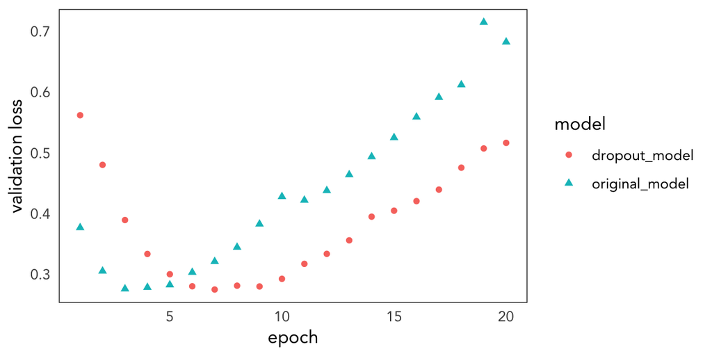

```r
df <- tibble(
  original_model = history$metrics$val_loss,
  dropout_model = history4$metrics$val_loss,
  epoch = 1:20)

df %>%
  gather(1:2, key = model, value = loss) %>%
  ggplot(aes(x = epoch, y = loss, color = model, shape = model)) +
  geom_point() +
  labs(y = "validation loss")
```

## Text and Sequences

Notes:

The two fundamental deep-learning algorithms for sequence processing are *recurrent* and 1D *convolutional* neural networks.

These models don’t understand text in a human sense; rather, they can map the statistical structure of written language. In other words, deep learning for natural-language processing is pattern recognition applied to words, sentences, and paragraphs.

*Vectorizing* text is the process of transforming text into numeric tensors. This is done by segmenting text into words or $n$-grams (and less commonly into characters). Collectively, the different units into which you can break down text (words, characters, or n-grams) are called tokens, and breaking text into such tokens is called *tokenization*. All text-vectorization processes consist of applying some tokenization scheme and then associating numeric vectors with the generated tokens.

There are multiple ways to associate a vector with a token, but only two of them are worth our time: **one-hot encoding** of tokens, and token **embedding** (typically used exclusively for words, and called word embedding).

A set of *unordered* tokens is commonly known as bag-of-words. This tokenization method tends to be used in shallow language-processing models (e.g. logistic regression and random forests) rather than in deep-learning models. Extracting $b$-grams is a form of feature engineering, and deep learning does away with this kind of rigid approach, replacing it with “hierarchical feature learning”. By looking at continuous word or character sequences, 1D convnets and recurrent neural networks are capable of learning representations for groups of words and characters without being explicitly told about the existence of such groups.

### One hot encoding

One hot encoding: it consists of associating a unique integer index with every word and then turning this integer index $i$ into a binary vector of size $N$ (the size of the vocabulary); the vector is all zeros except for the $i$th entry, which is 1.

For example:

```r
samples <- c("the cat sat on the cow", "the dog ate my homework", "the cow wrote a best selling book")

token_index <- list()
for (s in samples) {
  for (w in str_split(s, " ")[[1]]) {
    if (!w %in% names(token_index)) {
      ## Don't attribute anything to index 1
      token_index[[w]] <- length(token_index) + 2
    }
  }
}

results <- array(0, dim = c(length(samples), max(unlist(token_index))))
for (i in 1:length(samples)) {
  s <- samples[[i]]
  w <- str_split(s, " ")[[1]]
  for (n in 1:length(w)) {
    j <- token_index[[w[[n]]]]
    results[[i, j]] <- 1
  }
}

colnames(results) <- c("?", names(token_index))
results
```

```
     ? the cat sat on cow dog ate my homework wrote a best selling book
[1,] 0   1   1   1  1   1   0   0  0        0     0 0    0       0    0
[2,] 0   1   0   0  0   0   1   1  1        1     0 0    0       0    0
[3,] 0   1   0   0  0   1   0   0  0        0     1 1    1       1    1
```

```r
library(tokenizers)
tokens <- tokenize_words(samples)

results <- cbind(
  "?" = 0,
  tibble(text = tokens, id = 1:length(samples)) %>%
    unnest() %>%
    distinct(id, text) %>%
    mutate(n = 1) %>%   ## one-hot encoding
    tidytext::cast_sparse(id, text, n)
  )

results[, 1:8]
```

```
3 x 8 sparse Matrix of class "dgCMatrix"
  ? the cat sat on cow dog ate
1 .   1   1   1  1   1   .   .
2 .   1   .   .  .   .   1   1
3 .   1   .   .  .   1   .   .
```

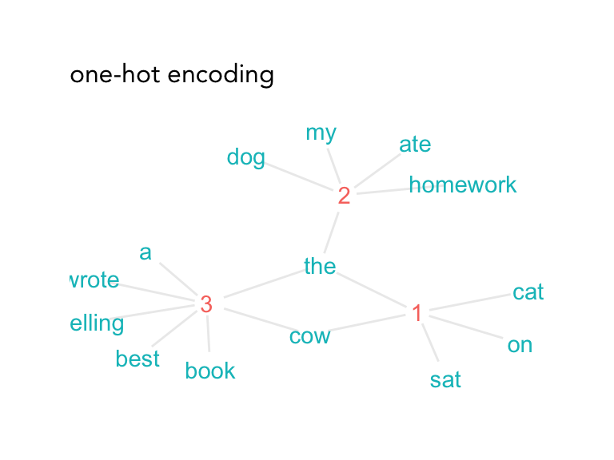

```r
library(ggraph)
tibble(text = samples) %>%
  mutate(id = row_number()) %>%
  tidytext::unnest_tokens(word, text) %>%
  distinct() %>%
  as.matrix() %>%
  igraph::graph_from_edgelist(directed = FALSE) %>%
  ggraph("kk") +
  geom_edge_fan(colour = "grey", alpha = 0.3,
        end_cap = circle(0.3, "cm"),
        start_cap = circle(0.2, "cm")) +
  geom_node_text(aes(label = name, color = !str_detect(name, "\\d")),
                 show.legend = FALSE) +
  theme_graph(base_family = "Avenir") +
  labs(subtitle = "one-hot encoding")
```

```r
library(keras)
tokenizer <- text_tokenizer(num_words = 15) %>%
  fit_text_tokenizer(samples)

one_hot_results <- texts_to_matrix(tokenizer, samples, mode = "binary")
colnames(one_hot_results) <- c("?", names(tokenizer$word_index))
one_hot_results
```

```
     ? the cow cat sat on dog ate my homework wrote a best selling book
[1,] 0   1   1   1   1  1   0   0  0        0     0 0    0       0    0
[2,] 0   1   0   0   0  0   1   1  1        1     0 0    0       0    0
[3,] 0   1   1   0   0  0   0   0  0        0     1 1    1       1    1
```

```r
cat("Found", length(tokenizer$word_index), "unique tokens.\n")
```

```
Found 14 unique tokens.
```

### Word embeddings

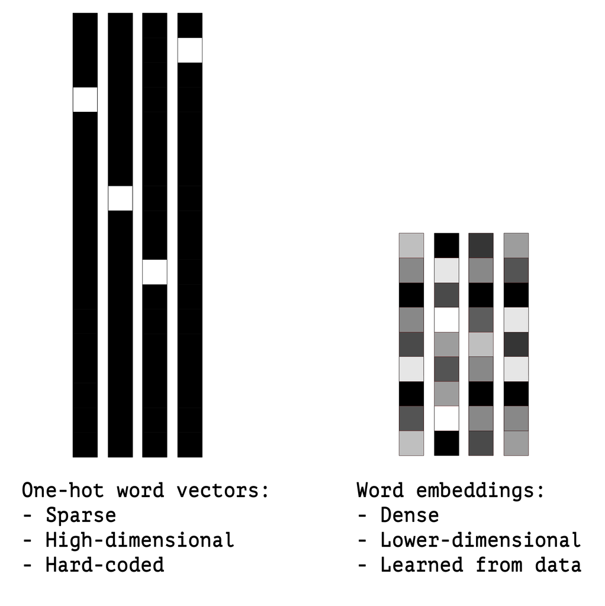

https://jjallaire.github.io/deep-learning-with-r-notebooks/notebooks/6.1-using-word-embeddings.nb.html

Also see: [Keras](https://blogs.rstudio.com/tensorflow/posts/2017-12-22-word-embeddings-with-keras/)

https://www.onceupondata.com/2019/01/21/keras-text-part1/